# Rural environment Paper

We plan a paper on the rural environment, based on data here: https://docs.google.com/document/d/18f048q1x7UAKwgjXP7UNRuAT6Ad3XBXZHAi3dFYO2U4/edit#heading=h.n0uc8s3dggzu .

If this is run with ORFCS data downloaded from the publicly available dataset, the results here might differ slightly from those presented in the paper. The results in the paper use unrounded BMIs (calculated from feet and inches) whereas the publicly avialalbe results have BMIs rounded to one decimal place, in order to protect anonmynity.

# Setup

```r
library(stringr)
library(rstatix)
library(foreign)
library(stringr)
library(dplyr)
```

```r
library(ggplot2)
library(data.table)
```

Set directories

```r
Sys.setenv(R_CONFIG_ACTIVE = Sys.info()["nodename"])
data_dir <- config::get("rural_data_dir")
hints5_filepath <- config::get("hints_protected_data_folderpath")
```

## Setup the ORFCS dataset

```r
source("orfcs_utilities.R")
library(magrittr)
library(dplyr)


#preprocessed_data_filepath <- paste0(data_dir,"cloudresearch_survey_results/orfcs_preprocessed2_anon_by_subj.csv")
preprocessed_data_filepath <- paste0(config::get("orfcs_shareable_folder"),"oregon_dataset_anon.csv")

library(readr)
library(ggplot2)
library(GGally)
orfcs_dataset <- readr::read_csv(preprocessed_data_filepath)
#have to do this here because the file was saved in CSV, which converts factors to strings.
orfcs_dataset$Education_Categorical<-factor(
  orfcs_dataset$Education_Categorical,
  #levels=3:9,
  labels=c("No high school diploma",
           "High school diploma/GED",
           "Some college credit, no degree",
           "Trade, technical, or vocational training",
           "Associate's degree",
           "Bachelor's degree",
           "Master's, Professional, or doctoral degree")
)

orfcs_dataset$Education_Ordinal<-as.integer(orfcs_dataset$Education_Categorical)
```

```r
source("orfcs_utilities.R")
library(magrittr)
library(dplyr)


#preprocessed_data_filepath <- paste0(data_dir,"cloudresearch_survey_results/orfcs_preprocessed2_anon_by_subj.csv")
preprocessed_data_filepath <- paste0(config::get("orfcs_shareable_folder"),"oregon_dataset_anon.csv")

library(readr)
library(ggplot2)
library(GGally)
orfcs_dataset2 <- readr::read_csv(preprocessed_data_filepath)
#have to do this here because the file was saved in CSV, which converts factors to strings.
orfcs_dataset2$Education_Categorical<-factor(
  orfcs_dataset2$Education_Categorical,
  #levels=3:9,
  labels=c("No high school diploma",
           "High school diploma/GED",
           "Some college credit, no degree",
           "Trade, technical, or vocational training",
           "Associate's degree",
           "Bachelor's degree",
           "Master's, Professional, or doctoral degree")
)

orfcs_dataset2$Education_Ordinal<-as.integer(orfcs_dataset2$Education_Categorical)
```

```r
#https://www.rdocumentation.org/packages/mediation/versions/4.5.0/topics/mediate
library(mediation)
boot_times = 10000 # set this to 10000 for final analysis, and 100 for setting up
```

## Set up the HINTS dataset

```r
source("HINTS_preprocessing.R")
hines_cycle5 <-get_hints5(hints5_filepath)
```

[output not shown]

```
## Note: Using an external vector in selections is ambiguous.
## ℹ Use `all_of(var_to_factorize)` instead of `var_to_factorize` to silence this message.
## ℹ See <https://tidyselect.r-lib.org/reference/faq-external-vector.html>.
```

# Summary stats

```r
orfcs_dataset %>% group_by(RuralZIP) %>% count()
```

| RuralZIP | n |
| --- | --- |
| FALSE | 458 |
| TRUE | 313 |
| NA | 79 |

```r
hines_cycle5 %>% group_by(HINTSIsRural) %>% count()
```

| HINTSIsRural | n |
| --- | --- |
| FALSE | 13912 |
| TRUE | 2180 |

#Findings

```r
#orfcs_dataset %>% filter(is.na(BMI)) %>% dplyr::select(WEIGHT,HEIGHT_m) %>% is.na %>% colSums
orfcs_dataset %>% filter(!is.na(BMI) & !is.na(RuralZIP) & !is.na(PSS_z) & !is.na(DEMO_Age_c) & !is.na(Gender3C) & !is.na(RaceC2)) %>% .$RuralZIP %>% table
```

```
## .
## FALSE  TRUE
##   382   244
```

```r
orfcs_dataset %>% filter(!is.na(cancer_promoting_minus_preventing_FFQ) & !is.na(Gender3C) & !is.na(RuralZIP) & !is.na(PSS_z) & !is.na(DEMO_Age_c) & !is.na(Gender3C) & !is.na(RaceC2)) %>% .$RuralZIP %>% table
```

```
## .
## FALSE  TRUE
##   439   296
```

```r
predict_ffq_rural <- lm(cancer_promoting_minus_preventing_FFQ~RuralZIP,
                  orfcs_dataset)
print(summary(predict_ffq_rural))
```

```
##
## Call:
## lm(formula = cancer_promoting_minus_preventing_FFQ ~ RuralZIP,
##     data = orfcs_dataset)
##
## Residuals:
##      Min       1Q   Median       3Q      Max
## -2.38565 -0.25626  0.07374  0.31404  1.73242
##
## Coefficients:
##              Estimate Std. Error t value Pr(>|t|)
## (Intercept)  -0.16935    0.02414  -7.016 5.02e-12 ***
## RuralZIPTRUE  0.02061    0.03788   0.544    0.587
## ---
## Signif. codes:  0 '***' 0.001 '**' 0.01 '*' 0.05 '.' 0.1 ' ' 1
##
## Residual standard error: 0.5166 on 769 degrees of freedom
##   (79 observations deleted due to missingness)
## Multiple R-squared:  0.0003847,  Adjusted R-squared:  -0.0009151
## F-statistic: 0.296 on 1 and 769 DF,  p-value: 0.5866
```

```r
print(confint(predict_ffq_rural))
```

```
##                    2.5 %      97.5 %
## (Intercept)  -0.21673043 -0.12196216
## RuralZIPTRUE -0.05375789  0.09497876
```

```r
predict_bmi_rural <- lm(BMI~RuralZIP,
                  orfcs_dataset)
print(summary(predict_bmi_rural))
```

```
##
## Call:
## lm(formula = BMI ~ RuralZIP, data = orfcs_dataset)
##
## Residuals:
##     Min      1Q  Median      3Q     Max
## -17.577  -5.429  -1.277   4.171  36.623
##
## Coefficients:
##              Estimate Std. Error t value Pr(>|t|)
## (Intercept)   28.0766     0.3780  74.276   <2e-16 ***
## RuralZIPTRUE   1.7524     0.6066   2.889    0.004 **
## ---
## Signif. codes:  0 '***' 0.001 '**' 0.01 '*' 0.05 '.' 0.1 ' ' 1
##
## Residual standard error: 7.532 on 647 degrees of freedom
##   (201 observations deleted due to missingness)
## Multiple R-squared:  0.01273,    Adjusted R-squared:  0.01121
## F-statistic: 8.345 on 1 and 647 DF,  p-value: 0.003997
```

```r
print(confint(predict_bmi_rural))
```

```
##                   2.5 %    97.5 %
## (Intercept)  27.3343143 28.818834
## RuralZIPTRUE  0.5612118  2.943576
```

```r
predict_bmi_rural <- lm(BMI~RuralZIP,
                  orfcs_dataset)
summary(predict_bmi_rural)
```

```
##
## Call:
## lm(formula = BMI ~ RuralZIP, data = orfcs_dataset)
##
## Residuals:
##     Min      1Q  Median      3Q     Max
## -17.577  -5.429  -1.277   4.171  36.623
##
## Coefficients:
##              Estimate Std. Error t value Pr(>|t|)
## (Intercept)   28.0766     0.3780  74.276   <2e-16 ***
## RuralZIPTRUE   1.7524     0.6066   2.889    0.004 **
## ---
## Signif. codes:  0 '***' 0.001 '**' 0.01 '*' 0.05 '.' 0.1 ' ' 1
##
## Residual standard error: 7.532 on 647 degrees of freedom
##   (201 observations deleted due to missingness)
## Multiple R-squared:  0.01273,    Adjusted R-squared:  0.01121
## F-statistic: 8.345 on 1 and 647 DF,  p-value: 0.003997
```

A post-hoc follow-up confirms this is a difference in a nationwide HINTS dataset

```r
data_to_measure <- hines_cycle5 %>%
  filter(SelfGender %in% c("Male","Female"))

summary(lm(BMI~HINTSIsRural_i+SelfGender+RacePP+filename,data_to_measure))
```

```
##
## Call:
## lm(formula = BMI ~ HINTSIsRural_i + SelfGender + RacePP + filename,
##     data = data_to_measure)
##
## Residuals:
##     Min      1Q  Median      3Q     Max
## -18.751  -4.427  -1.117   3.147  50.280
##
## Coefficients:
##                                         Estimate Std. Error t value Pr(>|t|)
## (Intercept)                            28.116590   0.141276 199.019  < 2e-16
## HINTSIsRural_i                          0.817462   0.158472   5.158 2.52e-07
## SelfGenderFemale                       -0.089438   0.109643  -0.816 0.414678
## RacePPBlack                             2.532513   0.152012  16.660  < 2e-16
## RacePPMissing data (Not Ascertained)    1.052597   0.275163   3.825 0.000131
## RacePPMultiple races selected           0.927910   0.288196   3.220 0.001286
## RacePPChinese                          -4.806698   0.514175  -9.348  < 2e-16
## RacePPFilipino                         -2.317002   0.544738  -4.253 2.12e-05
## RacePPAsian Indian                     -2.639947   0.573566  -4.603 4.21e-06
## RacePPOther Asian                      -3.346768   0.578802  -5.782 7.52e-09
## RacePPAmerican Indian or Alaska Native  1.539009   0.637427   2.414 0.015773
## RacePPPacific Islander                  2.061877   0.745034   2.767 0.005656
## RacePPVietnamese                       -5.873652   0.867222  -6.773 1.31e-11
## RacePPKorean                           -4.265697   1.111562  -3.838 0.000125
## RacePPJapanese                         -4.239445   1.246619  -3.401 0.000674
## filenamehints5_cycle2_public.sav       -0.006683   0.165487  -0.040 0.967785
## filenamehints5_cycle3_public.sav        0.034438   0.150887   0.228 0.819463
## filenamehints5_cycle4_public.sav        0.014171   0.162060   0.087 0.930319
##
## (Intercept)                            ***
## HINTSIsRural_i                         ***
## SelfGenderFemale
## RacePPBlack                            ***
## RacePPMissing data (Not Ascertained)   ***
## RacePPMultiple races selected          **
## RacePPChinese                          ***
## RacePPFilipino                         ***
## RacePPAsian Indian                     ***
## RacePPOther Asian                      ***
## RacePPAmerican Indian or Alaska Native *
## RacePPPacific Islander                 **
## RacePPVietnamese                       ***
## RacePPKorean                           ***
## RacePPJapanese                         ***
## filenamehints5_cycle2_public.sav
## filenamehints5_cycle3_public.sav
## filenamehints5_cycle4_public.sav
## ---
## Signif. codes:  0 '***' 0.001 '**' 0.01 '*' 0.05 '.' 0.1 ' ' 1
##
## Residual standard error: 6.466 on 14382 degrees of freedom
##   (332 observations deleted due to missingness)
## Multiple R-squared:  0.04034,    Adjusted R-squared:  0.03921
## F-statistic: 35.57 on 17 and 14382 DF,  p-value: < 2.2e-16
```

```r
#summary(lm(BMI~HINTSIsRural_i*SelfGender+RacePP+filename,data_to_measure))
```

```r
predict_bmi_rural <- lm(BMI~RuralZIP_i+
                    MESA_healthyfoodavailability_z+MESA_safetyfromcrime_z,
                  orfcs_dataset)
summary(predict_bmi_rural)
```

```
##
## Call:
## lm(formula = BMI ~ RuralZIP_i + MESA_healthyfoodavailability_z +
##     MESA_safetyfromcrime_z, data = orfcs_dataset)
##
## Residuals:
##     Min      1Q  Median      3Q     Max
## -18.323  -5.417  -1.202   4.098  35.329
##
## Coefficients:
##                                Estimate Std. Error t value Pr(>|t|)
## (Intercept)                     28.1008     0.3818  73.608  < 2e-16 ***
## RuralZIP_i                       1.7736     0.6235   2.845  0.00459 **
## MESA_healthyfoodavailability_z  -0.4061     0.3132  -1.296  0.19534
## MESA_safetyfromcrime_z          -0.5013     0.3138  -1.597  0.11065
## ---
## Signif. codes:  0 '***' 0.001 '**' 0.01 '*' 0.05 '.' 0.1 ' ' 1
##
## Residual standard error: 7.508 on 645 degrees of freedom
##   (201 observations deleted due to missingness)
## Multiple R-squared:  0.02187,    Adjusted R-squared:  0.01732
## F-statistic: 4.807 on 3 and 645 DF,  p-value: 0.002556
```

```r
set.seed(6472426)
library(mediation)

data_to_measure <- orfcs_dataset %>% filter(!is.na(BMI) & Gender3C %in% c("Male","Female"))

#Rurality -> Income -> BMI


mb <- lm(MESA_healthyfoodavailability_z~RuralZIP_i,data_to_measure)
mc <- lm(BMI~RuralZIP_i+MESA_healthyfoodavailability_z,data_to_measure)

mediate_result <- mediate(mb,mc,sims=boot_times, boot=TRUE,boot.ci.type = "bca", treat="RuralZIP_i",mediator="MESA_healthyfoodavailability_z")
```

```
## Running nonparametric bootstrap
```

```r
summary(mediate_result)
```

```
##
## Causal Mediation Analysis
##
## Nonparametric Bootstrap Confidence Intervals with the BCa Method
##
##                Estimate 95% CI Lower 95% CI Upper p-value
## ACME             0.1575      -0.0115         0.42  0.0968 .
## ADE              1.8253       0.6755         3.00  0.0012 **
## Total Effect     1.9828       0.8490         3.16  0.0006 ***
## Prop. Mediated   0.0794       0.0566         0.49  0.0974 .
## ---
## Signif. codes:  0 '***' 0.001 '**' 0.01 '*' 0.05 '.' 0.1 ' ' 1
##
## Sample Size Used: 641
##
##
## Simulations: 10000
```

```r
summary(mc)
```

```
##
## Call:
## lm(formula = BMI ~ RuralZIP_i + MESA_healthyfoodavailability_z,
##     data = data_to_measure)
##
## Residuals:
##     Min      1Q  Median      3Q     Max
## -17.733  -5.336  -1.136   4.064  36.206
##
## Coefficients:
##                                Estimate Std. Error t value Pr(>|t|)
## (Intercept)                     28.0134     0.3764  74.423   <2e-16 ***
## RuralZIP_i                       1.8253     0.6060   3.012   0.0027 **
## MESA_healthyfoodavailability_z  -0.4798     0.2988  -1.606   0.1088
## ---
## Signif. codes:  0 '***' 0.001 '**' 0.01 '*' 0.05 '.' 0.1 ' ' 1
##
## Residual standard error: 7.379 on 638 degrees of freedom
##   (5 observations deleted due to missingness)
## Multiple R-squared:  0.02083,    Adjusted R-squared:  0.01776
## F-statistic: 6.787 on 2 and 638 DF,  p-value: 0.001212
```

We could not do a follow-up with healthy food availability in the HINTS dataset because we have no MESA measure in the HINTS dataset.

```r
predict_bmi_rural <- lm(BMI~RuralZIP_i+
                    MESA_healthyfoodavailability_z+MESA_safetyfromcrime_z,
                  orfcs_dataset)
summary(predict_bmi_rural)
```

```
##
## Call:
## lm(formula = BMI ~ RuralZIP_i + MESA_healthyfoodavailability_z +
##     MESA_safetyfromcrime_z, data = orfcs_dataset)
##
## Residuals:
##     Min      1Q  Median      3Q     Max
## -18.323  -5.417  -1.202   4.098  35.329
##
## Coefficients:
##                                Estimate Std. Error t value Pr(>|t|)
## (Intercept)                     28.1008     0.3818  73.608  < 2e-16 ***
## RuralZIP_i                       1.7736     0.6235   2.845  0.00459 **
## MESA_healthyfoodavailability_z  -0.4061     0.3132  -1.296  0.19534
## MESA_safetyfromcrime_z          -0.5013     0.3138  -1.597  0.11065
## ---
## Signif. codes:  0 '***' 0.001 '**' 0.01 '*' 0.05 '.' 0.1 ' ' 1
##
## Residual standard error: 7.508 on 645 degrees of freedom
##   (201 observations deleted due to missingness)
## Multiple R-squared:  0.02187,    Adjusted R-squared:  0.01732
## F-statistic: 4.807 on 3 and 645 DF,  p-value: 0.002556
```

```r
set.seed(4794382)
library(mediation)

data_to_measure <- orfcs_dataset %>% filter(!is.na(BMI) & Gender3C %in% c("Male","Female"))

#Rurality -> Income -> BMI


mb <- lm(MESA_healthyfoodavailability_z~RuralZIP_i,data_to_measure)
mc <- lm(BMI~RuralZIP_i+MESA_healthyfoodavailability_z,data_to_measure)

mediate_result <- mediate(mb,mc,sims=boot_times, boot=TRUE,boot.ci.type = "bca", treat="RuralZIP_i",mediator="MESA_healthyfoodavailability_z")
```

```
## Running nonparametric bootstrap
```

```r
summary(mediate_result)
```

```
##
## Causal Mediation Analysis
##
## Nonparametric Bootstrap Confidence Intervals with the BCa Method
##
##                Estimate 95% CI Lower 95% CI Upper p-value
## ACME             0.1575      -0.0112         0.44  0.1032
## ADE              1.8253       0.6513         2.97  0.0028 **
## Total Effect     1.9828       0.8140         3.14  0.0008 ***
## Prop. Mediated   0.0794       0.0165         0.35  0.1040
## ---
## Signif. codes:  0 '***' 0.001 '**' 0.01 '*' 0.05 '.' 0.1 ' ' 1
##
## Sample Size Used: 641
##
##
## Simulations: 10000
```

```r
summary(mc)
```

```
##
## Call:
## lm(formula = BMI ~ RuralZIP_i + MESA_healthyfoodavailability_z,
##     data = data_to_measure)
##
## Residuals:
##     Min      1Q  Median      3Q     Max
## -17.733  -5.336  -1.136   4.064  36.206
##
## Coefficients:
##                                Estimate Std. Error t value Pr(>|t|)
## (Intercept)                     28.0134     0.3764  74.423   <2e-16 ***
## RuralZIP_i                       1.8253     0.6060   3.012   0.0027 **
## MESA_healthyfoodavailability_z  -0.4798     0.2988  -1.606   0.1088
## ---
## Signif. codes:  0 '***' 0.001 '**' 0.01 '*' 0.05 '.' 0.1 ' ' 1
##
## Residual standard error: 7.379 on 638 degrees of freedom
##   (5 observations deleted due to missingness)
## Multiple R-squared:  0.02083,    Adjusted R-squared:  0.01776
## F-statistic: 6.787 on 2 and 638 DF,  p-value: 0.001212
```

## Analyses on household Income

### Household income mediates the BMI-rurality relationship

In the Oregon data:

```r
set.seed(2498714)

library(mediation)

data_to_measure <- orfcs_dataset %>% dplyr::filter(!is.na(BMI)) %>% dplyr::filter(!is.na(BMI) & Gender3C %in% c("Male","Female"))

#Rurality -> Income -> BMI


mb <- lm(aSES_02_z~RuralZIP_i#+
         ,data_to_measure)
mc <- lm(BMI~RuralZIP_i+aSES_02_z#+
         ,data_to_measure)

mediate_result <- mediate(mb,mc,sims=boot_times,boot=TRUE,boot.ci.type = "bca",
                          treat="RuralZIP_i",mediator="aSES_02_z")
```

```
## Running nonparametric bootstrap
```

```r
summary(mediate_result)
```

```
##
## Causal Mediation Analysis
##
## Nonparametric Bootstrap Confidence Intervals with the BCa Method
##
##                Estimate 95% CI Lower 95% CI Upper p-value
## ACME              0.412        0.186         0.74  <2e-16 ***
## ADE               1.555        0.413         2.72  0.0088 **
## Total Effect      1.967        0.821         3.14  0.0012 **
## Prop. Mediated    0.210        0.114         0.96  0.0012 **
## ---
## Signif. codes:  0 '***' 0.001 '**' 0.01 '*' 0.05 '.' 0.1 ' ' 1
##
## Sample Size Used: 633
##
##
## Simulations: 10000
```

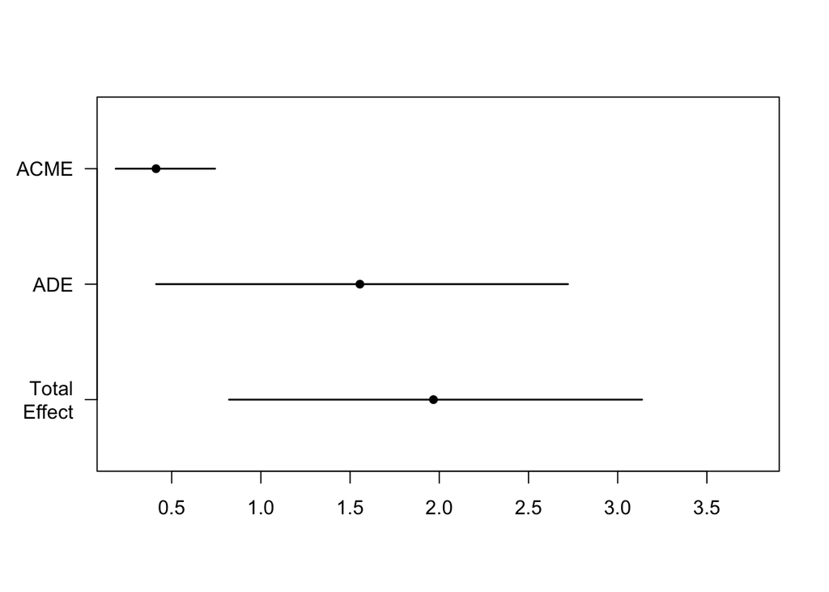

```r
plot(mediate_result)
```

```r
summary(mc)
```

```
##
## Call:
## lm(formula = BMI ~ RuralZIP_i + aSES_02_z, data = data_to_measure)
##
## Residuals:
##     Min      1Q  Median      3Q     Max
## -19.050  -5.250  -1.230   4.251  36.391
##
## Coefficients:
##             Estimate Std. Error t value Pr(>|t|)
## (Intercept)  28.1905     0.3787  74.444  < 2e-16 ***
## RuralZIP_i    1.5550     0.6046   2.572 0.010347 *
## aSES_02_z    -1.1443     0.2952  -3.877 0.000117 ***
## ---
## Signif. codes:  0 '***' 0.001 '**' 0.01 '*' 0.05 '.' 0.1 ' ' 1
##
## Residual standard error: 7.315 on 630 degrees of freedom
##   (13 observations deleted due to missingness)
## Multiple R-squared:  0.03957,    Adjusted R-squared:  0.03652
## F-statistic: 12.98 on 2 and 630 DF,  p-value: 3e-06
```

and in the nationwide HINTS dataset:

```r
set.seed(2708803)
#model is:
data_to_measure <- hines_cycle5 %>%
  filter( !is.na(HHInc_r) & !is.na(BMI) & Gender3C %in% c("Male","Female"))


#Rurality -> Income -> BMI
mb <- lm(HHInc_r~HINTSIsRural_i+Fruit_vegetables_z,data_to_measure)
mc <- lm(BMI~HINTSIsRural_i+Fruit_vegetables_z+HHInc_r,data_to_measure)

income_mediation <- mediate(mb,mc,sims=boot_times, boot=TRUE,boot.ci.type = "bca",
                            treat="HINTSIsRural_i",mediator="HHInc_r")
```

```
## Running nonparametric bootstrap
```

```r
summary(income_mediation)
```

```
##
## Causal Mediation Analysis
##
## Nonparametric Bootstrap Confidence Intervals with the BCa Method
##
##                Estimate 95% CI Lower 95% CI Upper p-value
## ACME              0.182        0.119         0.26  <2e-16 ***
## ADE               0.965        0.425         1.50   2e-04 ***
## Total Effect      1.147        0.595         1.69   2e-04 ***
## Prop. Mediated    0.159        0.108         0.46   2e-04 ***
## ---
## Signif. codes:  0 '***' 0.001 '**' 0.01 '*' 0.05 '.' 0.1 ' ' 1
##
## Sample Size Used: 6054
##
##
## Simulations: 10000
```

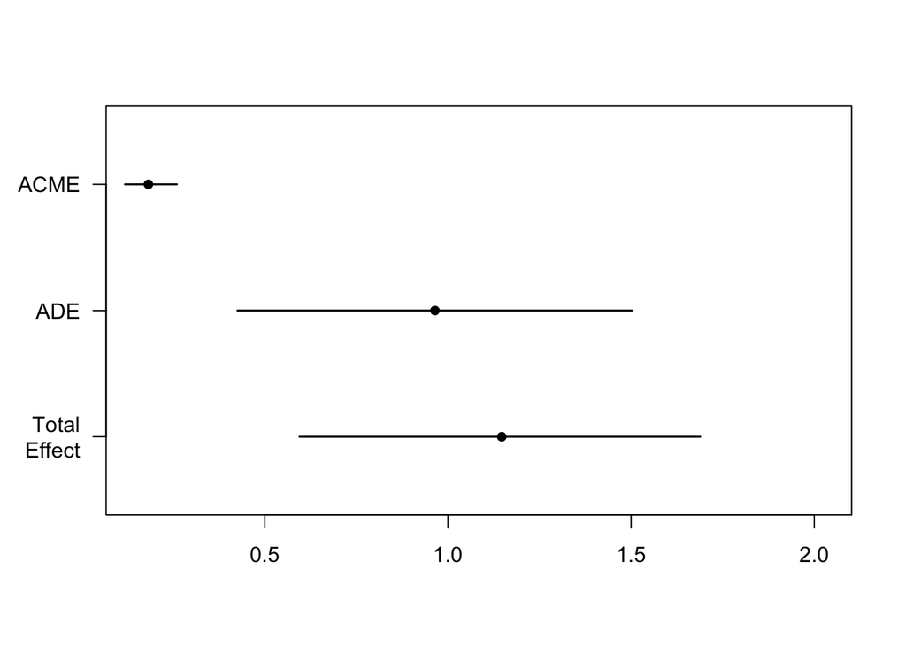

```r
plot(income_mediation)
```

```r
#lm(HHInc_r~BMIdata_to_measure$,data_to_measure$)
cor.test(data_to_measure$HHInc_r,as.numeric(data_to_measure$HINTSIsRural_i))
```

```
##
##  Pearson's product-moment correlation
##
## data:  data_to_measure$HHInc_r and as.numeric(data_to_measure$HINTSIsRural_i)
## t = -10.028, df = 13427, p-value < 2.2e-16
## alternative hypothesis: true correlation is not equal to 0
## 95 percent confidence interval:
##  -0.10298124 -0.06940564
## sample estimates:
##         cor
## -0.08621792
```

```r
summary(mc)
```

```
##
## Call:
## lm(formula = BMI ~ HINTSIsRural_i + Fruit_vegetables_z + HHInc_r,
##     data = data_to_measure)
##
## Residuals:
##     Min      1Q  Median      3Q     Max
## -20.197  -4.416  -1.133   3.196  44.925
##
## Coefficients:
##                    Estimate Std. Error t value Pr(>|t|)
## (Intercept)        28.16504    0.09235 304.990  < 2e-16 ***
## HINTSIsRural_i      0.96462    0.24943   3.867 0.000111 ***
## Fruit_vegetables_z -0.62288    0.08428  -7.391 1.66e-13 ***
## HHInc_r            -0.45631    0.05504  -8.291  < 2e-16 ***
## ---
## Signif. codes:  0 '***' 0.001 '**' 0.01 '*' 0.05 '.' 0.1 ' ' 1
##
## Residual standard error: 6.436 on 6050 degrees of freedom
##   (7375 observations deleted due to missingness)
## Multiple R-squared:  0.02756,    Adjusted R-squared:  0.02708
## F-statistic: 57.16 on 3 and 6050 DF,  p-value: < 2.2e-16
```

### household income mediates the rurality-food availability relationship in the Oregon data

```r
library(mediation)
set.seed(45348321)
data_to_measure <- orfcs_dataset %>% filter(!is.na(MESA_healthyfoodavailability_z)) %>% filter(!is.na(MESA_healthyfoodavailability_z) & Gender3C %in% c("Male","Female"))

#Rurality -> Income -> BMI


mb <- lm(aSES_02_z~RuralZIP_i
         ,data_to_measure)
mc <- lm(MESA_healthyfoodavailability~RuralZIP_i+aSES_02_z
         ,data_to_measure)

mediate_result <- mediate(mb,mc,sims=boot_times,boot=TRUE,boot.ci.type = "bca",
                          treat="RuralZIP_i",mediator="aSES_02_z")
```

```
## Running nonparametric bootstrap
```

```r
summary(mediate_result)
```

```
##
## Causal Mediation Analysis
##
## Nonparametric Bootstrap Confidence Intervals with the BCa Method
##
##                Estimate 95% CI Lower 95% CI Upper p-value
## ACME            -0.0682      -0.1109        -0.04  <2e-16 ***
## ADE             -0.2316      -0.3627        -0.09   8e-04 ***
## Total Effect    -0.2997      -0.4323        -0.17  <2e-16 ***
## Prop. Mediated   0.2274       0.1293         0.56  <2e-16 ***
## ---
## Signif. codes:  0 '***' 0.001 '**' 0.01 '*' 0.05 '.' 0.1 ' ' 1
##
## Sample Size Used: 745
##
##
## Simulations: 10000
```

```r
summary(mc)
```

```
##
## Call:
## lm(formula = MESA_healthyfoodavailability ~ RuralZIP_i + aSES_02_z,
##     data = data_to_measure)
##
## Residuals:
##      Min       1Q   Median       3Q      Max
## -3.03557 -0.47066  0.07038  0.57854  1.57038
##
## Coefficients:
##             Estimate Std. Error t value Pr(>|t|)
## (Intercept)  3.86631    0.04249  91.004  < 2e-16 ***
## RuralZIP_i  -0.23158    0.06696  -3.458 0.000574 ***
## aSES_02_z    0.17267    0.03296   5.239 2.11e-07 ***
## ---
## Signif. codes:  0 '***' 0.001 '**' 0.01 '*' 0.05 '.' 0.1 ' ' 1
##
## Residual standard error: 0.882 on 742 degrees of freedom
##   (18 observations deleted due to missingness)
## Multiple R-squared:  0.06108,    Adjusted R-squared:  0.05855
## F-statistic: 24.13 on 2 and 742 DF,  p-value: 7.003e-11
```

### The food availability mediation above disappears when controlling for income…

```r
set.seed(54948339)
data_to_measure <- orfcs_dataset %>% filter(!is.na(BMI)) %>% filter(!is.na(BMI) & Gender3C %in% c("Male","Female"))

#Rurality -> Income -> BMI
#

mb <- lm(MESA_healthyfoodavailability~RuralZIP_i+
           aSES_02_z
           #FFQ_cancer_preventing+FFQ_cancer_promoting+
           # IPAQ_total_METminutes+
           # MESA_neighborhoodconnectedness+
           # MESA_safetyfromcrime+
           # EDM_mean+
            # cancer_promoting_minus_preventing_liked_FCI+
            # cancer_promoting_minus_preventing_craved_FCI
         ,data_to_measure)
mc <- lm(BMI~RuralZIP_i+MESA_healthyfoodavailability_z+
           aSES_02_z
           #FFQ_cancer_preventing+FFQ_cancer_promoting+
           # IPAQ_total_METminutes+
           # MESA_neighborhoodconnectedness+
           # MESA_safetyfromcrime+
           # EDM_mean+
            # cancer_promoting_minus_preventing_liked_FCI+
            # cancer_promoting_minus_preventing_craved_FCI
         ,data_to_measure)

mediate_result <- mediate(mb,mc,sims=boot_times,boot=TRUE,boot.ci.type = "bca",
                          treat="RuralZIP_i",mediator="MESA_healthyfoodavailability_z")
```

```
## Running nonparametric bootstrap
```

```r
summary(mediate_result)
```

```
##
## Causal Mediation Analysis
##
## Nonparametric Bootstrap Confidence Intervals with the BCa Method
##
##                Estimate 95% CI Lower 95% CI Upper p-value
## ACME             0.0725      -0.0518         0.28   0.328
## ADE              1.4761       0.3151         2.65   0.014 *
## Total Effect     1.5486       0.3918         2.73   0.010 *
## Prop. Mediated   0.0468      -0.0285         0.44   0.334
## ---
## Signif. codes:  0 '***' 0.001 '**' 0.01 '*' 0.05 '.' 0.1 ' ' 1
##
## Sample Size Used: 633
##
##
## Simulations: 10000
```

```r
summary(mc)
```

```
##
## Call:
## lm(formula = BMI ~ RuralZIP_i + MESA_healthyfoodavailability_z +
##     aSES_02_z, data = data_to_measure)
##
## Residuals:
##     Min      1Q  Median      3Q     Max
## -19.172  -5.226  -1.110   4.252  36.063
##
## Coefficients:
##                                Estimate Std. Error t value Pr(>|t|)
## (Intercept)                     28.2316     0.3811  74.084  < 2e-16 ***
## RuralZIP_i                       1.4761     0.6102   2.419 0.015839 *
## MESA_healthyfoodavailability_z  -0.2908     0.3005  -0.968 0.333542
## aSES_02_z                       -1.1004     0.2986  -3.685 0.000249 ***
## ---
## Signif. codes:  0 '***' 0.001 '**' 0.01 '*' 0.05 '.' 0.1 ' ' 1
##
## Residual standard error: 7.316 on 629 degrees of freedom
##   (13 observations deleted due to missingness)
## Multiple R-squared:  0.04099,    Adjusted R-squared:  0.03642
## F-statistic: 8.963 on 3 and 629 DF,  p-value: 8.056e-06
```

### …and income mediates the relationship between food availability and BMI across the Oregon dataset

```r
set.seed(33527146)

data_to_measure <- orfcs_dataset %>% filter(!is.na(BMI)) %>% filter(!is.na(BMI) & Gender3C %in% c("Male","Female") & !is.na(PSS_z))

#Rurality -> Income -> BMI
#

mb <- lm(aSES_02_z~MESA_healthyfoodavailability_z
         ,data_to_measure)
mc <- lm(BMI~MESA_healthyfoodavailability_z+aSES_02_z
         ,data_to_measure)

mediate_result <- mediate(mb,mc,sims=boot_times,boot=TRUE,boot.ci.type = "bca",
                          treat="MESA_healthyfoodavailability_z",mediator="aSES_02_z")
```

```
## Running nonparametric bootstrap
```

```r
summary(mediate_result)
```

```
##
## Causal Mediation Analysis
##
## Nonparametric Bootstrap Confidence Intervals with the BCa Method
##
##                Estimate 95% CI Lower 95% CI Upper p-value
## ACME             -0.215       -0.384        -0.10  <2e-16 ***
## ADE              -0.425       -1.019         0.14    0.14
## Total Effect     -0.639       -1.246        -0.07    0.03 *
## Prop. Mediated    0.336        0.179        10.01    0.03 *
## ---
## Signif. codes:  0 '***' 0.001 '**' 0.01 '*' 0.05 '.' 0.1 ' ' 1
##
## Sample Size Used: 638
##
##
## Simulations: 10000
```

```r
#summary(mb)
summary(mc)
```

```
##
## Call:
## lm(formula = BMI ~ MESA_healthyfoodavailability_z + aSES_02_z,
##     data = data_to_measure)
##
## Residuals:
##     Min      1Q  Median      3Q     Max
## -19.924  -5.292  -1.179   4.185  35.338
##
## Coefficients:
##                                Estimate Std. Error t value Pr(>|t|)
## (Intercept)                     28.8128     0.2913  98.909  < 2e-16 ***
## MESA_healthyfoodavailability_z  -0.4245     0.2970  -1.429    0.153
## aSES_02_z                       -1.1931     0.2947  -4.048 5.81e-05 ***
## ---
## Signif. codes:  0 '***' 0.001 '**' 0.01 '*' 0.05 '.' 0.1 ' ' 1
##
## Residual standard error: 7.335 on 635 degrees of freedom
##   (8 observations deleted due to missingness)
## Multiple R-squared:  0.03226,    Adjusted R-squared:  0.02921
## F-statistic: 10.58 on 2 and 635 DF,  p-value: 3.008e-05
```

## fruit consumption and healthy food availability

### Post-hoc: BMI-Fruit & Veggies relationship holds for the Oregon and HINTs datasets

#### Oregon

```r
predict_bmi_rural <- lm(BMI~FFQ_fruit_vegetables_z,
                  orfcs_dataset)
summary(predict_bmi_rural)
```

```
##
## Call:
## lm(formula = BMI ~ FFQ_fruit_vegetables_z, data = orfcs_dataset)
##
## Residuals:
##     Min      1Q  Median      3Q     Max
## -17.896  -5.285  -0.995   4.036  35.840
##
## Coefficients:
##                        Estimate Std. Error t value Pr(>|t|)
## (Intercept)             28.7187     0.2929  98.040  < 2e-16 ***
## FFQ_fruit_vegetables_z  -1.1165     0.2950  -3.785 0.000168 ***
## ---
## Signif. codes:  0 '***' 0.001 '**' 0.01 '*' 0.05 '.' 0.1 ' ' 1
##
## Residual standard error: 7.497 on 653 degrees of freedom
##   (195 observations deleted due to missingness)
## Multiple R-squared:  0.02147,    Adjusted R-squared:  0.01997
## F-statistic: 14.32 on 1 and 653 DF,  p-value: 0.000168
```

#### HINTS

```r
data_to_measure <- hines_cycle5


summary(lm(BMI~Fruit_vegetables_z,data_to_measure))
```

```
##
## Call:
## lm(formula = BMI ~ Fruit_vegetables_z, data = data_to_measure)
##
## Residuals:
##     Min      1Q  Median      3Q     Max
## -19.669  -4.427  -1.255   3.231  46.987
##
## Coefficients:
##                    Estimate Std. Error t value Pr(>|t|)
## (Intercept)        28.47077    0.07734  368.10   <2e-16 ***
## Fruit_vegetables_z -0.71726    0.07754   -9.25   <2e-16 ***
## ---
## Signif. codes:  0 '***' 0.001 '**' 0.01 '*' 0.05 '.' 0.1 ' ' 1
##
## Residual standard error: 6.473 on 7003 degrees of freedom
##   (9087 observations deleted due to missingness)
## Multiple R-squared:  0.01207,    Adjusted R-squared:  0.01193
## F-statistic: 85.56 on 1 and 7003 DF,  p-value: < 2.2e-16
```

```r
summary(lm(BMI~Fruit_vegetables_z,data_to_measure))
```

```
##
## Call:
## lm(formula = BMI ~ Fruit_vegetables_z, data = data_to_measure)
##
## Residuals:
##     Min      1Q  Median      3Q     Max
## -19.669  -4.427  -1.255   3.231  46.987
##
## Coefficients:
##                    Estimate Std. Error t value Pr(>|t|)
## (Intercept)        28.47077    0.07734  368.10   <2e-16 ***
## Fruit_vegetables_z -0.71726    0.07754   -9.25   <2e-16 ***
## ---
## Signif. codes:  0 '***' 0.001 '**' 0.01 '*' 0.05 '.' 0.1 ' ' 1
##
## Residual standard error: 6.473 on 7003 degrees of freedom
##   (9087 observations deleted due to missingness)
## Multiple R-squared:  0.01207,    Adjusted R-squared:  0.01193
## F-statistic: 85.56 on 1 and 7003 DF,  p-value: < 2.2e-16
```

```r
summary(lm(BMI~Fruit_vegetables_z+I(Fruit_vegetables_z^2),data_to_measure))
```

```
##
## Call:
## lm(formula = BMI ~ Fruit_vegetables_z + I(Fruit_vegetables_z^2),
##     data = data_to_measure)
##
## Residuals:
##     Min      1Q  Median      3Q     Max
## -19.667  -4.422  -1.261   3.233  46.996
##
## Coefficients:
##                         Estimate Std. Error t value Pr(>|t|)
## (Intercept)             28.46059    0.09665 294.482   <2e-16 ***
## Fruit_vegetables_z      -0.71806    0.07768  -9.244   <2e-16 ***
## I(Fruit_vegetables_z^2)  0.01023    0.05822   0.176    0.861
## ---
## Signif. codes:  0 '***' 0.001 '**' 0.01 '*' 0.05 '.' 0.1 ' ' 1
##
## Residual standard error: 6.474 on 7002 degrees of freedom
##   (9087 observations deleted due to missingness)
## Multiple R-squared:  0.01207,    Adjusted R-squared:  0.01179
## F-statistic: 42.79 on 2 and 7002 DF,  p-value: < 2.2e-16
```

### Fruit (and vegetable???) consumption mediates the relationship between healthy food availability and BMI

#### Oregon

```r
set.seed(25296177)

data_to_measure <- orfcs_dataset %>% filter(!is.na(BMI) & !is.na(MESA_healthyfoodavailability_z) & !is.na(FFQ_fruit_vegetables_z) & !is.na(RuralZIP) &Gender3C %in% c("Female", "Male"))

# treatment MESA_healthyfoodavailability
# mediator FFQ_fruits_ln_z

mb <- lm(FFQ_fruit_vegetables_z~MESA_healthyfoodavailability_z,data_to_measure)
mc <- lm(BMI~            MESA_healthyfoodavailability_z+FFQ_fruit_vegetables_z,data_to_measure)

mediate_result <- mediate(mb,mc,sims=boot_times,boot=TRUE,boot.ci.type = "bca",
                          treat="MESA_healthyfoodavailability_z",mediator="FFQ_fruit_vegetables_z")
```

```
## Running nonparametric bootstrap
```

```r
summary(mediate_result)
```

```
##
## Causal Mediation Analysis
##
## Nonparametric Bootstrap Confidence Intervals with the BCa Method
##
##                Estimate 95% CI Lower 95% CI Upper p-value
## ACME             -0.145       -0.297        -0.05  0.0032 **
## ADE              -0.480       -1.073         0.11  0.1096
## Total Effect     -0.626       -1.218        -0.05  0.0360 *
## Prop. Mediated    0.232        0.111         8.37  0.0384 *
## ---
## Signif. codes:  0 '***' 0.001 '**' 0.01 '*' 0.05 '.' 0.1 ' ' 1
##
## Sample Size Used: 641
##
##
## Simulations: 10000
```

```r
summary(mb)
```

```
##
## Call:
## lm(formula = FFQ_fruit_vegetables_z ~ MESA_healthyfoodavailability_z,
##     data = data_to_measure)
##
## Residuals:
##      Min       1Q   Median       3Q      Max
## -2.35820 -0.75208 -0.03891  0.71255  2.78176
##
## Coefficients:
##                                Estimate Std. Error t value Pr(>|t|)
## (Intercept)                    -0.01743    0.03906  -0.446 0.655494
## MESA_healthyfoodavailability_z  0.14641    0.03946   3.710 0.000225 ***
## ---
## Signif. codes:  0 '***' 0.001 '**' 0.01 '*' 0.05 '.' 0.1 ' ' 1
##
## Residual standard error: 0.9877 on 639 degrees of freedom
## Multiple R-squared:  0.02108,    Adjusted R-squared:  0.01955
## F-statistic: 13.76 on 1 and 639 DF,  p-value: 0.0002254
```

```r
summary(mc)
```

```
##
## Call:
## lm(formula = BMI ~ MESA_healthyfoodavailability_z + FFQ_fruit_vegetables_z,
##     data = data_to_measure)
##
## Residuals:
##     Min      1Q  Median      3Q     Max
## -18.146  -5.258  -0.940   3.937  35.382
##
## Coefficients:
##                                Estimate Std. Error t value Pr(>|t|)
## (Intercept)                     28.7123     0.2914  98.544  < 2e-16 ***
## MESA_healthyfoodavailability_z  -0.4805     0.2975  -1.615 0.106793
## FFQ_fruit_vegetables_z          -0.9905     0.2951  -3.357 0.000835 ***
## ---
## Signif. codes:  0 '***' 0.001 '**' 0.01 '*' 0.05 '.' 0.1 ' ' 1
##
## Residual standard error: 7.367 on 638 degrees of freedom
## Multiple R-squared:  0.02414,    Adjusted R-squared:  0.02108
## F-statistic: 7.892 on 2 and 638 DF,  p-value: 0.0004114
```

#### HINTS

```r
set.seed(96734053)
data_to_measure <- hines_cycle5 %>%
  filter(!is.na(HHInc_r) & !is.na(BMI) & !is.na(Fruit_vegetables_z))


#Rurality -> Income -> BMI
mb <- lm(Fruit_vegetables_z~HINTSIsRural_i+HHInc_r,data_to_measure)
mc <- lm(BMI~HINTSIsRural_i+HHInc_r+Fruit_vegetables_z,data_to_measure)

vegetables_mediation <- mediate(mb,mc,sims=boot_times, boot=TRUE,boot.ci.type = "bca",
                                treat="HINTSIsRural_i",mediator="Fruit_vegetables_z")
```

```
## Running nonparametric bootstrap
```

```r
summary(vegetables_mediation)
```

```
##
## Causal Mediation Analysis
##
## Nonparametric Bootstrap Confidence Intervals with the BCa Method
##
##                Estimate 95% CI Lower 95% CI Upper p-value
## ACME            0.04509      0.00128         0.10  0.0506 .
## ADE             0.86996      0.34702         1.42  0.0008 ***
## Total Effect    0.91504      0.39447         1.46  0.0002 ***
## Prop. Mediated  0.04927      0.00937         0.19  0.0508 .
## ---
## Signif. codes:  0 '***' 0.001 '**' 0.01 '*' 0.05 '.' 0.1 ' ' 1
##
## Sample Size Used: 6324
##
##
## Simulations: 10000
```

```r
summary(mc)
```

```
##
## Call:
## lm(formula = BMI ~ HINTSIsRural_i + HHInc_r + Fruit_vegetables_z,
##     data = data_to_measure)
##
## Residuals:
##     Min      1Q  Median      3Q     Max
## -20.206  -4.419  -1.130   3.187  45.008
##
## Coefficients:
##                    Estimate Std. Error t value Pr(>|t|)
## (Intercept)        28.16629    0.09100 309.521  < 2e-16 ***
## HINTSIsRural_i      0.86996    0.24445   3.559 0.000375 ***
## HHInc_r            -0.45993    0.05350  -8.597  < 2e-16 ***
## Fruit_vegetables_z -0.62281    0.08265  -7.536 5.55e-14 ***
## ---
## Signif. codes:  0 '***' 0.001 '**' 0.01 '*' 0.05 '.' 0.1 ' ' 1
##
## Residual standard error: 6.444 on 6320 degrees of freedom
## Multiple R-squared:  0.02711,    Adjusted R-squared:  0.02665
## F-statistic:  58.7 on 3 and 6320 DF,  p-value: < 2.2e-16
```

## fruit consumption and rurality (mainly interesting as a general proxy for healthy eating)

```r
set.seed(70213575)

#Rurality -> Income -> BMI
mb <- lm(Fruit_vegetables_z~HINTSIsRural_i+HHInc_r,data_to_measure)
mc <- lm(BMI~HINTSIsRural_i+HHInc_r+Fruit_vegetables_z,data_to_measure)

fruit_mediation <- mediate(mb,mc,sims=boot_times, boot=TRUE,boot.ci.type = "bca",
                           treat="HINTSIsRural_i",mediator="Fruit_vegetables_z")
```

```
## Running nonparametric bootstrap
```

```r
summary(fruit_mediation)
```

```
##
## Causal Mediation Analysis
##
## Nonparametric Bootstrap Confidence Intervals with the BCa Method
##
##                 Estimate 95% CI Lower 95% CI Upper p-value
## ACME            0.045087    -0.000194         0.09  0.0546 .
## ADE             0.869957     0.344101         1.41  0.0008 ***
## Total Effect    0.915044     0.392969         1.46  0.0004 ***
## Prop. Mediated  0.049273     0.011136         0.23  0.0550 .
## ---
## Signif. codes:  0 '***' 0.001 '**' 0.01 '*' 0.05 '.' 0.1 ' ' 1
##
## Sample Size Used: 6324
##
##
## Simulations: 10000
```

```r
summary(mc)
```

```
##
## Call:
## lm(formula = BMI ~ HINTSIsRural_i + HHInc_r + Fruit_vegetables_z,
##     data = data_to_measure)
##
## Residuals:
##     Min      1Q  Median      3Q     Max
## -20.206  -4.419  -1.130   3.187  45.008
##
## Coefficients:
##                    Estimate Std. Error t value Pr(>|t|)
## (Intercept)        28.16629    0.09100 309.521  < 2e-16 ***
## HINTSIsRural_i      0.86996    0.24445   3.559 0.000375 ***
## HHInc_r            -0.45993    0.05350  -8.597  < 2e-16 ***
## Fruit_vegetables_z -0.62281    0.08265  -7.536 5.55e-14 ***
## ---
## Signif. codes:  0 '***' 0.001 '**' 0.01 '*' 0.05 '.' 0.1 ' ' 1
##
## Residual standard error: 6.444 on 6320 degrees of freedom
## Multiple R-squared:  0.02711,    Adjusted R-squared:  0.02665
## F-statistic:  58.7 on 3 and 6320 DF,  p-value: < 2.2e-16
```

```r
set.seed(30567291)

data_to_measure <- orfcs_dataset %>% filter(!is.na(BMI) & !is.na(MESA_healthyfoodavailability_z) & !is.na(FFQ_fruit_vegetables_z) & !is.na(RuralZIP_i) & Gender3C %in% c("Female", "Male"))



mb <- lm(FFQ_fruit_vegetables_z~RuralZIP_i+MESA_healthyfoodavailability_z,data_to_measure)
mc <- lm(BMI~            RuralZIP_i+MESA_healthyfoodavailability_z+FFQ_fruit_vegetables_z,data_to_measure)

mediate_result <- mediate(mb,mc,sims=boot_times, boot=TRUE,boot.ci.type = "bca",
                          treat="RuralZIP_i",mediator="FFQ_fruit_vegetables_z")
```

```
## Running nonparametric bootstrap
```

```r
summary(mediate_result)
```

```
##
## Causal Mediation Analysis
##
## Nonparametric Bootstrap Confidence Intervals with the BCa Method
##
##                Estimate 95% CI Lower 95% CI Upper p-value
## ACME            -0.0920      -0.3064         0.06  0.2648
## ADE              1.9173       0.7751         3.06  0.0012 **
## Total Effect     1.8253       0.6665         2.98  0.0024 **
## Prop. Mediated  -0.0504      -0.5518         0.01  0.2672
## ---
## Signif. codes:  0 '***' 0.001 '**' 0.01 '*' 0.05 '.' 0.1 ' ' 1
##
## Sample Size Used: 641
##
##
## Simulations: 10000
```

```r
summary(mb)
```

```
##
## Call:
## lm(formula = FFQ_fruit_vegetables_z ~ RuralZIP_i + MESA_healthyfoodavailability_z,
##     data = data_to_measure)
##
## Residuals:
##      Min       1Q   Median       3Q      Max
## -2.33285 -0.74348 -0.04838  0.69254  2.73338
##
## Coefficients:
##                                Estimate Std. Error t value Pr(>|t|)
## (Intercept)                    -0.05244    0.05037  -1.041 0.298217
## RuralZIP_i                      0.08923    0.08109   1.100 0.271601
## MESA_healthyfoodavailability_z  0.15353    0.03999   3.840 0.000135 ***
## ---
## Signif. codes:  0 '***' 0.001 '**' 0.01 '*' 0.05 '.' 0.1 ' ' 1
##
## Residual standard error: 0.9875 on 638 degrees of freedom
## Multiple R-squared:  0.02294,    Adjusted R-squared:  0.01988
## F-statistic: 7.489 on 2 and 638 DF,  p-value: 0.0006096
```

```r
summary(mc)
```

```
##
## Call:
## lm(formula = BMI ~ RuralZIP_i + MESA_healthyfoodavailability_z +
##     FFQ_fruit_vegetables_z, data = data_to_measure)
##
## Residuals:
##     Min      1Q  Median      3Q     Max
## -17.309  -5.348  -0.938   3.951  36.289
##
## Coefficients:
##                                Estimate Std. Error t value Pr(>|t|)
## (Intercept)                     27.9593     0.3734  74.875  < 2e-16 ***
## RuralZIP_i                       1.9173     0.6012   3.189 0.001497 **
## MESA_healthyfoodavailability_z  -0.3215     0.2996  -1.073 0.283546
## FFQ_fruit_vegetables_z          -1.0312     0.2932  -3.516 0.000468 ***
## ---
## Signif. codes:  0 '***' 0.001 '**' 0.01 '*' 0.05 '.' 0.1 ' ' 1
##
## Residual standard error: 7.314 on 637 degrees of freedom
## Multiple R-squared:  0.03948,    Adjusted R-squared:  0.03495
## F-statistic: 8.727 on 3 and 637 DF,  p-value: 1.114e-05
```